# A5_Tasks

## A5_T1 Main program

Create a Python program, which contains a `main`-function. The program must print the content in the same way as in the example program run below, but only from within the `main`-function. Top-level print commands are not allowed. The `main`-function must also return `None` value at the end of the function.

**Example program run**

```
Program starting.
Hello from main function!
Program ending.
```

## A5_T2 Pass argument

Create Python program which is able to print user input with a decorative frame.

Program must consist of two functions:

- `main`-function
  - Print starting and ending statements.
  - Print any empty row (see example program run)
  - Prompt user to insert a word.
  - Pass the inserted word into the `frameWord`-function.
  - Returns `None`
- `frameWord`
  - Takes `PWord` as a parameter.
  - Prints the framing and the `PWord`
    - Hint: Multiply the asterisk `'*'`-character.
  - Returns `None`

Note! Tests for this task relies on properly defined functions and may fail if the program is not written according to the instructions.

**Example program runs**

```
Program starting.
Insert word: Beautiful

*************
* Beautiful *
*************

Program ending.
```

```
Program starting.
Insert word: Unbelievable

****************
* Unbelievable *
****************

Program ending.
```

```
Program starting.
Insert word: Done

********
* Done *
********

Program ending.
```

## A5_T3 Ask name

Create a Python program with two functions:

- `main`-function
  - Does the routines (`"Program starting."` and `"Program ending."`)
  - Utilizes `askName`-function.
  - Utilizes `greetUser`-function.
  - Returns `None`
- `askName`-function
  - Prompts the user to insert name
  - Returns name
- `greetUser`-function
  - Which takes `PName` as an argument
  - Greets the user `"Hello {PName}!"`
  - Returns `None`

Note! Tests for this task relies on properly defined functions and may fail if the program is not written according to the instructions.

```
Program starting.
Insert name: John
Hello John!
Program ending.
```

```
Program starting.
Insert name: Alice
Hello Alice!
Program ending.
```

```
Program starting.
Insert name: Bob
Hello Bob!
Program ending.
```

## A5_T4 Multiple parameter

The following code should calculate the area of a rectangle based on the user inputs.

Fix the example code below without altering defined function names or function parameters. Fixed code must produce similar results as is in the expected program runs. The code must also be fixed to match the requirements in the provided **style guide**.

```python
def askDimension(PPrompt: str) -> float:
   Feed = input("Insert number: ")
   return Feed

Width = askNumber("width")
Height = askNumber("height")

def calcRectangleArea(PWidth: float, PHeight: float) -> float:
   PWidth = Area * PHeight
   return Sum

Area = calculateArea()
print("")
print("Area is {Area}²")
print("end")
```

**Expected program runs**

```
Program starting.
Insert width: 2
Insert height: 3

Area is 6.0²
Program ending.
```

```
Program starting.
Insert width: 3
Insert height: 3

Area is 9.0²
Program ending.
```

```
Program starting.
Insert width: 123
Insert height: 345

Area is 42435.0²
Program ending.
```

## A5_T5 Menu-driven program

Create a menu-driven Python program with following options:

1. Insert a word
   1. Which stores user inserted word into memory.
2. Show current word
   1. Prints the word from the memory
3. Show current word in reverse
   1. Prints the word from the memory in reverse.
4. Exit
   1. Stops the program gracefully
5. Unknown option

Initialize the `Word` with an empty string.

**Example program runs**

```
Program starting.
Options:
1 - Insert word
2 - Show current word
3 - Show current word in reverse
0 - Exit
Your choice: 1
Insert word: Banana

Options:
1 - Insert word
2 - Show current word
3 - Show current word in reverse
0 - Exit
Your choice: 2
Current word - "Banana"

Options:
1 - Insert word
2 - Show current word
3 - Show current word in reverse
0 - Exit
Your choice: 3
Word reversed - "ananaB"

Options:
1 - Insert word
2 - Show current word
3 - Show current word in reverse
0 - Exit
Your choice: 0
Exiting program.

Program ending.
```

```
Program starting.
Options:
1 - Insert word
2 - Show current word
3 - Show current word in reverse
0 - Exit
Your choice: 2
Current word - ""

Options:
1 - Insert word
2 - Show current word
3 - Show current word in reverse
0 - Exit
Your choice: 3
Word reversed - ""

Options:
1 - Insert word
2 - Show current word
3 - Show current word in reverse
0 - Exit
Your choice: 0
Exiting program.

Program ending.
```

```
Program starting.
Options:
1 - Insert word
2 - Show current word
3 - Show current word in reverse
0 - Exit
Your choice: 4
Unknown option! try again.

Options:
1 - Insert word
2 - Show current word
3 - Show current word in reverse
0 - Exit
Your choice: 1
Insert word: Done

Options:
1 - Insert word
2 - Show current word
3 - Show current word in reverse
0 - Exit
Your choice: 2
Current word - "Done"

Options:
1 - Insert word
2 - Show current word
3 - Show current word in reverse
0 - Exit
Your choice: 0
Exiting program.

Program ending.
```

```
Program starting.
Options:
1 - Insert word
2 - Show current word
3 - Show current word in reverse
0 - Exit
Your choice: 3
Word reversed - ""

Options:
1 - Insert word
2 - Show current word
3 - Show current word in reverse
0 - Exit
Your choice: 0
Exiting program.

Program ending.
```

## A5_T6 Tally counter (TEST TASK)

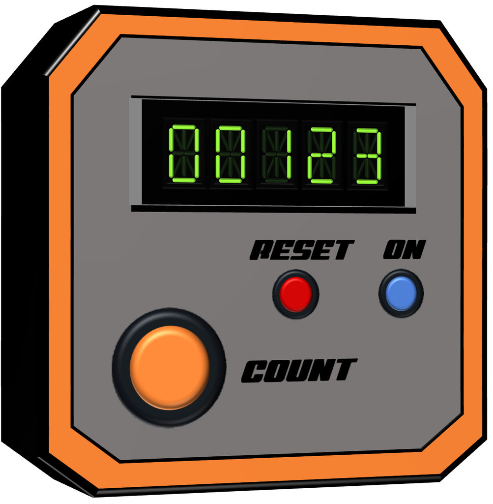

Make a menu-driven Python program which mimics Tally Counter.

This menu-driven program must contain a maintainable program structure with the following requirements:

1. **main** function which represents the main program logic including menu cycle.
2. **showOptions** function which takes no arguments, shows the available options in the standard output and returns `None`.
3. **askChoice** function which takes no arguments, prompts user to insert choice and returns an integer regardless of the user feed.

In case user incorrectly inserts text as a choice, the program must output `"Unknown option!"`. For this, see the string method `isnumeric()` behaviour described in [W3S](https://www.w3schools.com/python/ref_string_isnumeric.asp) or via [Python documentation](https://docs.python.org/3/library/stdtypes.html#str.isnumeric).

See other requirements in the example program runs below.

**Example program runs**

```
Program starting.
Options:
1 - Show count
2 - Increase count
3 - Reset count
0 - Exit
Your choice: 1
Current count - 0

Options:
1 - Show count
2 - Increase count
3 - Reset count
0 - Exit
Your choice: 0
Exiting program.

Program ending.
```

```
Program starting.
Options:
1 - Show count
2 - Increase count
3 - Reset count
0 - Exit
Your choice: 2
Count increased!

Options:
1 - Show count
2 - Increase count
3 - Reset count
0 - Exit
Your choice: 1
Current count - 1

Options:
1 - Show count
2 - Increase count
3 - Reset count
0 - Exit
Your choice: 0
Exiting program.

Program ending.
```

```
Program starting.
Options:
1 - Show count
2 - Increase count
3 - Reset count
0 - Exit
Your choice: 1
Current count - 0

Options:
1 - Show count
2 - Increase count
3 - Reset count
0 - Exit
Your choice: 2
Count increased!

Options:
1 - Show count
2 - Increase count
3 - Reset count
0 - Exit
Your choice: 3
Cleared count!

Options:
1 - Show count
2 - Increase count
3 - Reset count
0 - Exit
Your choice: 1
Current count - 0

Options:
1 - Show count
2 - Increase count
3 - Reset count
0 - Exit
Your choice: 0
Exiting program.

Program ending.
```

```
Program starting.
Options:
1 - Show count
2 - Increase count
3 - Reset count
0 - Exit
Your choice: 4
Unknown option!

Options:
1 - Show count
2 - Increase count
3 - Reset count
0 - Exit
Your choice: 0
Exiting program.

Program ending.
```

```
Program starting.
Options:
1 - Show count
2 - Increase count
3 - Reset count
0 - Exit
Your choice: 2
Count increased!

Options:
1 - Show count
2 - Increase count
3 - Reset count
0 - Exit
Your choice: 2
Count increased!

Options:
1 - Show count
2 - Increase count
3 - Reset count
0 - Exit
Your choice: 2
Count increased!

Options:
1 - Show count
2 - Increase count
3 - Reset count
0 - Exit
Your choice: 1
Current count - 3

Options:
1 - Show count
2 - Increase count
3 - Reset count
0 - Exit
Your choice: 0
Exiting program.

Program ending.
```

```
Program starting.
Options:
1 - Show count
2 - Increase count
3 - Reset count
0 - Exit
Your choice: Show count
Unknown option!

Options:
1 - Show count
2 - Increase count
3 - Reset count
0 - Exit
Your choice: a
Unknown option!

Options:
1 - Show count
2 - Increase count
3 - Reset count
0 - Exit
Your choice: 1 - Show count
Unknown option!

Options:
1 - Show count
2 - Increase count
3 - Reset count
0 - Exit
Your choice: 1
Current count - 0

Options:
1 - Show count
2 - Increase count
3 - Reset count
0 - Exit
Your choice: 0
Exiting program.

Program ending.
```

## A5_T7 Words in a string (TEST TASK)

Create a Python program which collects words in a `collectWords`-function and analyses the words in a `analyseWords`-function. Use `main`-function to define the main logic.

Separate words with comma `','` delimiter. Define `DELIMITER` at the beginning of the program on the top-level as a constant variable.

**Main logic**

Call the `collectWords`-function and store the words into a local variable. Next pass the collected words to the `analyseWords`-function.

**Word collecting:**

Prompt user to insert word. Repeat the prompt till the user enters an empty word. Collect all words into one variable where each word is separated by a `DELIMITER`. At the end of the function, return the string variable holding all of the words.

**Analysing words:**

Takes one parameter containing words wrapped into one string. Calculates the amount of words, characters and the average word length. Separating words must happen by utilizing the `DELIMITER`. Finally displays the results. Average word length must be presented in 2 decimal precision. This function should not return anything.

Use `print("- {:.2f} Average word length".format(Avg))` to print average word length in 2 decimal precision.

**Example program runs**

```
Program starting.
Insert word(empty stops): change
Insert word(empty stops): is
Insert word(empty stops): constant
Insert word(empty stops):
- 3 Words
- 16 Characters
- 5.33 Average word length
Program ending.
```

```
Program starting.
Insert word(empty stops): challenges
Insert word(empty stops): help
Insert word(empty stops): us
Insert word(empty stops): grow
Insert word(empty stops): stronger
Insert word(empty stops):
- 5 Words
- 28 Characters
- 5.60 Average word length
Program ending.
```

```
Program starting.
Insert word(empty stops): enjoy
Insert word(empty stops): every
Insert word(empty stops): small
Insert word(empty stops): moment
Insert word(empty stops):
- 4 Words
- 21 Characters
- 5.25 Average word length
Program ending.
```